# Biostatistical Computing, PHC 6068

Simulating random variables

Zhiguang Huo (Caleb)

Wednesday October 30, 2019

# Outlines

- Simulating random variables
  - Direct simulation using R
  - Inverse CDF

# Random samples from a given pool of numbers

```r
a <- 1:10
sample(x = a, size = 2)
```

```
## [1] 7 1
```

```r
sample(x = a, size = 2)
```

```
## [1] 10  9
```

```r
sample(x = a, size = 2)
```

```
## [1] 7 8
```

# Are they really random? Can generate the same random number (for reproducibility)?

- The random numbers generated in R are not truly random, they are **pseudorandom**.
- So we are able to reproduce the exact same random numbers by setting random seeds.

```r
a <- 1:10
set.seed(32611) ## 32611 can be replaced by any number
sample(x = a, size = 2)
```

```
## [1] 1 7
```

```r
set.seed(32611) ## if you keep the same random seed, you will end up with the exact same result
sample(x = a, size = 2)
```

```
## [1] 1 7
```

```r
set.seed(32611) ## if you keep the same random seed, you will end up with the exact same result
sample(x = a, size = 2)
```

```
## [1] 1 7
```

# Each time the seed is set, the same sequence follows

```r
set.seed(32611)
sample(1:10,2); sample(1:10,2); sample(1:10,2)
```

```
## [1] 1 7
```

```
## [1] 3 7
```

```
## [1] 8 5
```

```r
set.seed(32611)
sample(1:10,2); sample(1:10,2); sample(1:10,2)
```

```
## [1] 1 7
```

```
## [1] 3 7
```

```
## [1] 8 5
```

# Want to sample from a given pool of numbers with replacement

```r
sample(1:10) ## default is without replacement
```

```
##  [1]  5  1  2  6 10  7  3  9  4  8
```

```r
sample(1:10, replace = T) ## with replacement
```

```
##  [1]  6  5  5  7  3  7  3  1 10  7
```

```r
sample(LETTERS[1:10], replace = T) ## with replacement
```

```
##  [1] "I" "I" "B" "D" "H" "E" "A" "J" "F" "D"
```

# Random number generation from normal distribution

For normal distribution:

- rnorm(): generate random variable from normal distribution
- pnorm(): get CDF/pvalue from normal distribution, $\Phi(x) = P(Z \le x)$
- dnorm(): normal density function $\phi = \Phi'(x)$
- qnorm(): quantile function for normal distribution $q(y) = \Phi^{-1}(y)$ such that $\Phi(q(y)) = y$

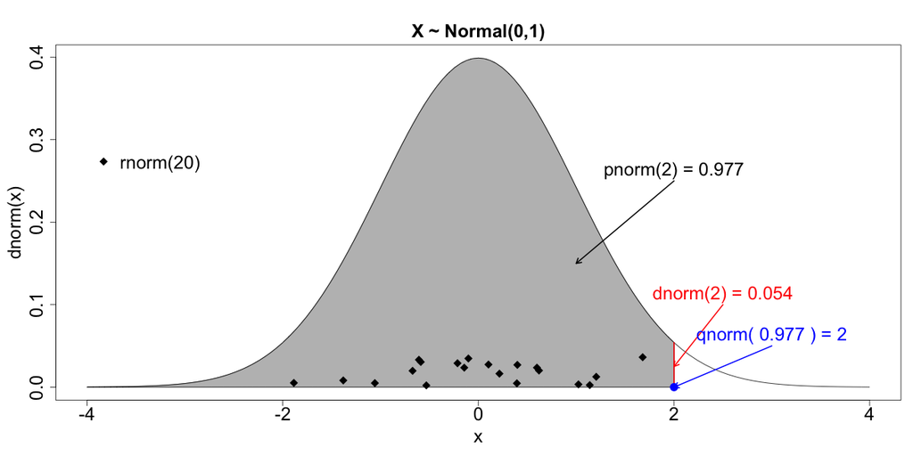

# Random variable simulators in R

| Distribution | R command |
| --- | --- |
| binomial | rbinom |
| Poisson | rpois |
| geometric | rgeom |
| negative binomial | rnbinom |
| uniform | runif |
| exponential | rexp |
| normal | rnorm |
| gamma | rgamma |
| beta | rbeta |
| student t | rt |
| F | rf |
| chi-squared | rchisq |
| Weibull | rweibull |
| log normal | rlnorm |

# Random variable density in R

| Distribution | R command |
| --- | --- |
| binomial | dbinom |
| Poisson | dpois |
| geometric | dgeom |
| negative binomial | dnbinom |
| uniform | dunif |
| exponential | dexp |
| normal | dnorm |
| gamma | dgamma |
| beta | dbeta |
| student t | dt |
| F | df |
| chi-squared | dchisq |
| Weibull | dweibull |
| log normal | dlnorm |

# Random variable distribution tail probablity in R

| Distribution | R command |
| --- | --- |
| binomial | pbinom |
| Poisson | ppois |
| geometric | pgeom |
| negative binomial | pnbinom |
| uniform | punif |
| exponential | pexp |
| normal | pnorm |
| gamma | pgamma |
| beta | pbeta |
| student t | pt |
| F | pf |
| chi-squared | pchisq |
| Weibull | pweibull |
| log normal | plnorm |

# Random variable distribution quantile in R

| Distribution | R command |
| --- | --- |
| binomial | qbinom |
| Poisson | qpois |
| geometric | qgeom |
| negative binomial | qnbinom |
| uniform | qunif |
| exponential | qexp |
| normal | qnorm |
| gamma | qgamma |
| beta | qbeta |
| student t | qt |
| F | qf |
| chi-squared | qchisq |
| Weibull | qweibull |
| log normal | qlnorm |

# Normal distribution

$$f(x;\mu,\sigma) = \frac{1}{\sqrt{2\pi \sigma^2}} e^{-\frac{(x-\mu)^2}{2\sigma^2}}$$

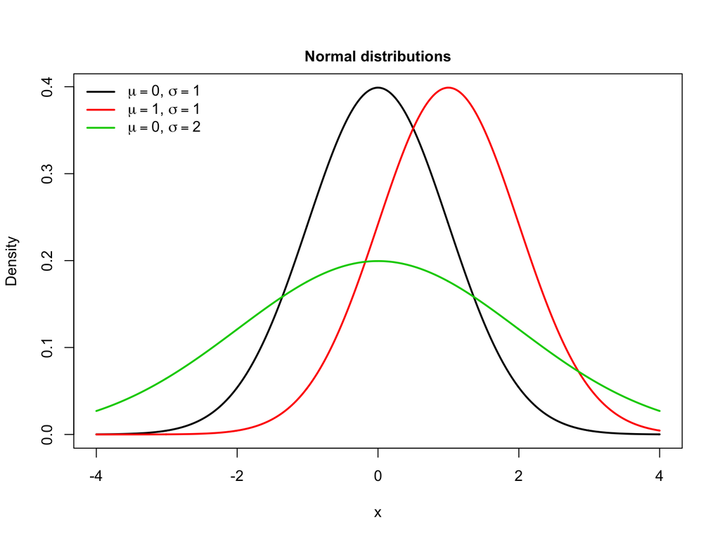

```r
aseq <- seq(-4,4,.01)
plot(aseq,dnorm(aseq, 0, 1),type='l', xlab='x', ylab='Density', lwd=2)
lines(aseq,dnorm(aseq, 1, 1),col=2, lwd=2)
lines(aseq,dnorm(aseq,0, 2),col=3, lwd=2)
legend("topleft",c(expression(paste(mu==0, ", " ,  sigma==1 ,sep=' ')),
             expression(paste(mu==1, ", " ,  sigma==1 ,sep=' ')),
             expression(paste(mu==0, ", " ,  sigma==2 ,sep=' '))),
       col=1:3, lty=c(1,1,1), lwd=c(2,2,2), cex=1, bty='n')
mtext(side=3,line=.5,'Normal distributions',cex=1, font=2)
```

# t distribution

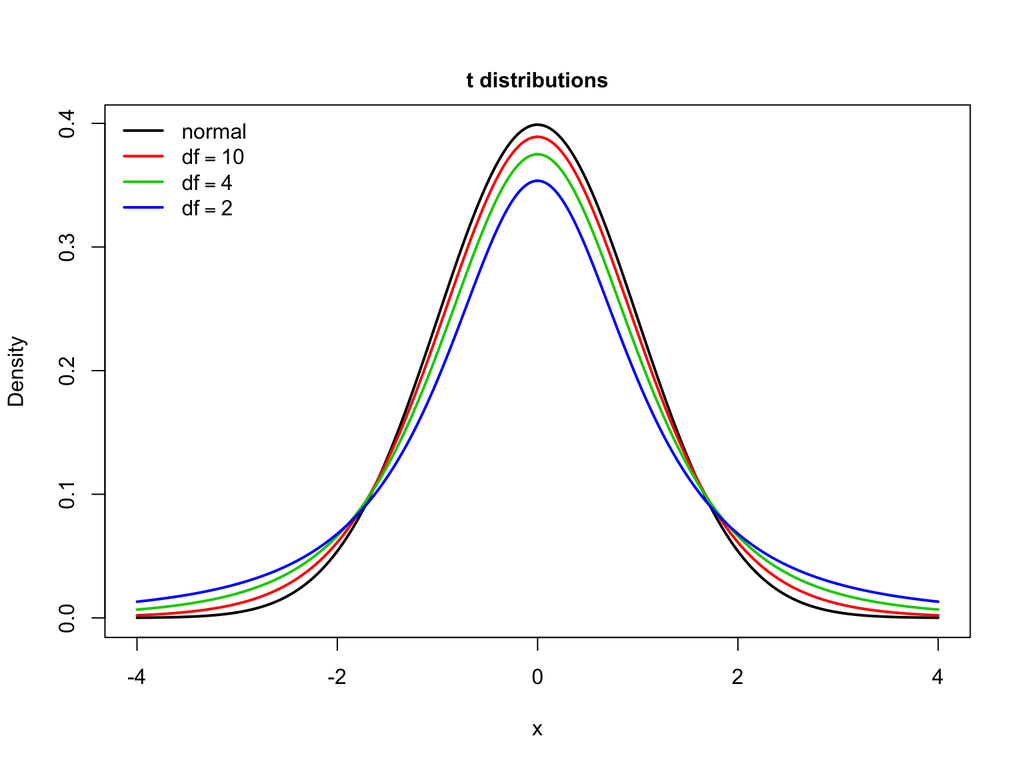

```r
aseq <- seq(-4,4,.01)
plot(aseq,dnorm(aseq),type='l', xlab='x', ylab='Density', lwd=2)
lines(aseq,dt(aseq,10),col=2, lwd=2)
lines(aseq,dt(aseq,4),col=3, lwd=2)
lines(aseq,dt(aseq,2),col=4, lwd=2)
legend("topleft",c(expression(normal), expression(paste(df==10,sep=' ')),
             expression(paste(df==4,sep=' ')),
             expression(paste(df==2,sep=' '))),
       col=1:4, lty=c(1,1,1), lwd=c(2,2,2), cex=1, bty='n')
mtext(side=3,line=.5,'t distributions',cex=1, font=2)
```

# Chi-square distribution

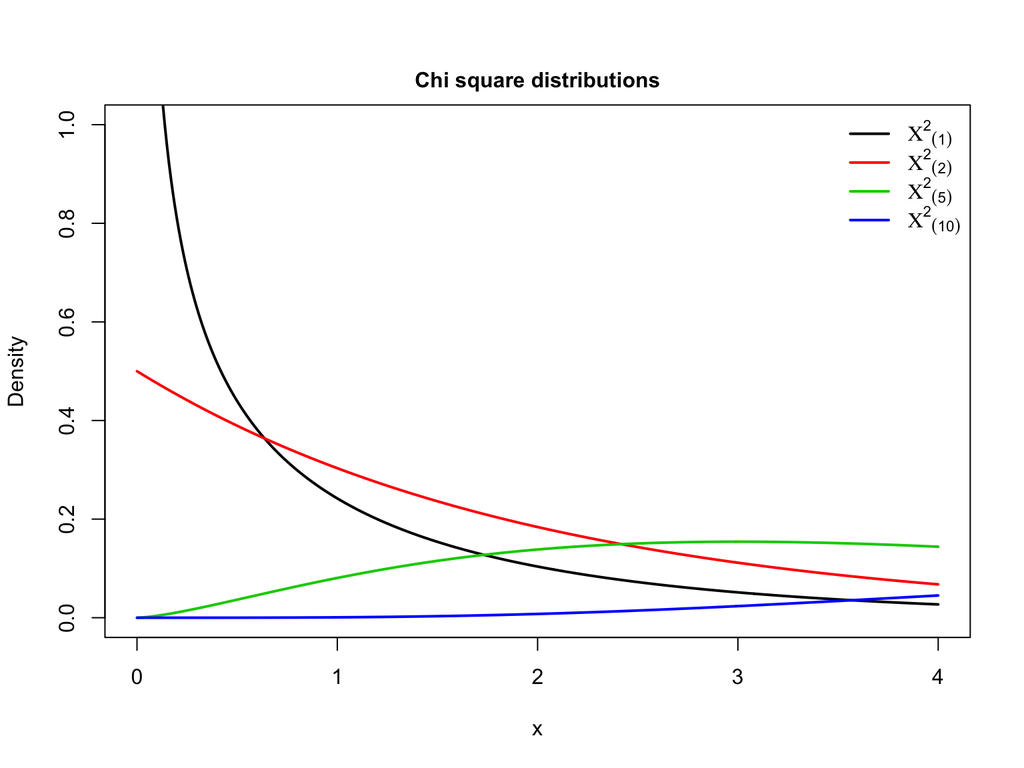

```r
aseq <- seq(0,4,.01)
plot(aseq,dchisq(aseq, df = 1),type='l', xlab='x', ylab='Density', lwd=2, ylim = c(0,1))
lines(aseq,dchisq(aseq,df = 2),col=2, lwd=2)
lines(aseq,dchisq(aseq,df = 5),col=3, lwd=2)
lines(aseq,dchisq(aseq,df = 10),col=4, lwd=2)
legend("topright",c(expression({Chi^2}[(1)]), expression({Chi^2}[(2)]),
             expression({Chi^2}[(5)]),
             expression({Chi^2}[(10)])
             ),
       col=1:4, lty=c(1,1,1), lwd=c(2,2,2), cex=1, bty='n')
mtext(side=3,line=.5,'Chi square distributions',cex=1, font=2)
```

# Chi-square distribution

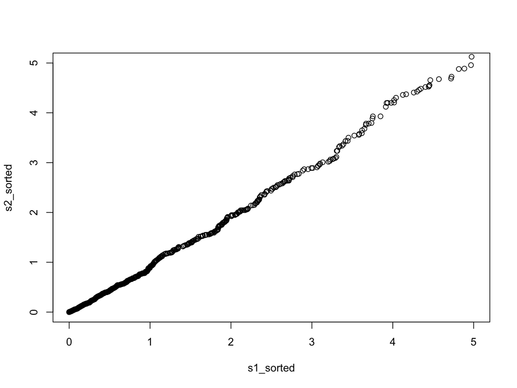

```r
## verification via qq-plot
set.seed(32608)
n <- 1000
x1 <- rnorm(n)
x2 <- rchisq(n,df = 1)
## the best practice is to use the theoretical distribution
## for simplicity, we can also use the emperical distribution

s1_sorted <- sort(x1^2)
s2_sorted <- sort(x2)

plot(s1_sorted, s2_sorted, xlim = c(0,5), ylim = c(0,5))
```

# Poisson distribution

$$f(k;\lambda) = \frac{\lambda^k e^{-\lambda}}{k!},$$
where $k$ is non negative integer.

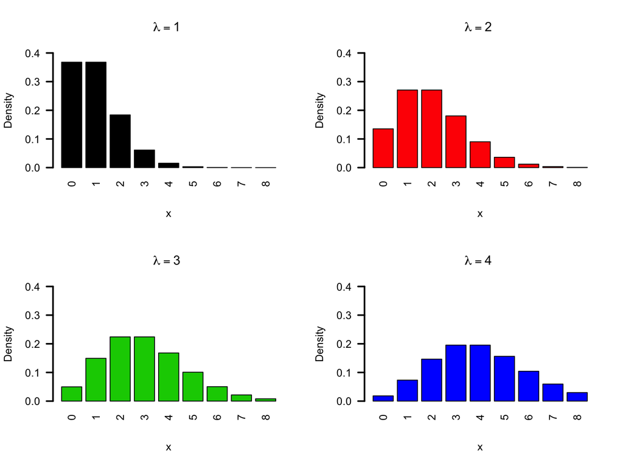

```r
aseq <- seq(0,8,1)
par(mfrow=c(2,2))
for(i in 1:4){
  counts <- dpois(aseq,i)
  names(counts) <- aseq
  barplot(counts, xlab='x', ylab='Density', lwd=2, col=i, las = 2,  main=bquote(paste(lambda==.(i), sep=' ')), ylim=c(0, 0.4))
}
```

# Beta distribution

$$f(x;\alpha,\beta) = \frac{\Gamma(\alpha + \beta)}{\Gamma(\alpha) \Gamma(\beta)} x^{\alpha - 1}(1 - x)^{\beta - 1}$$

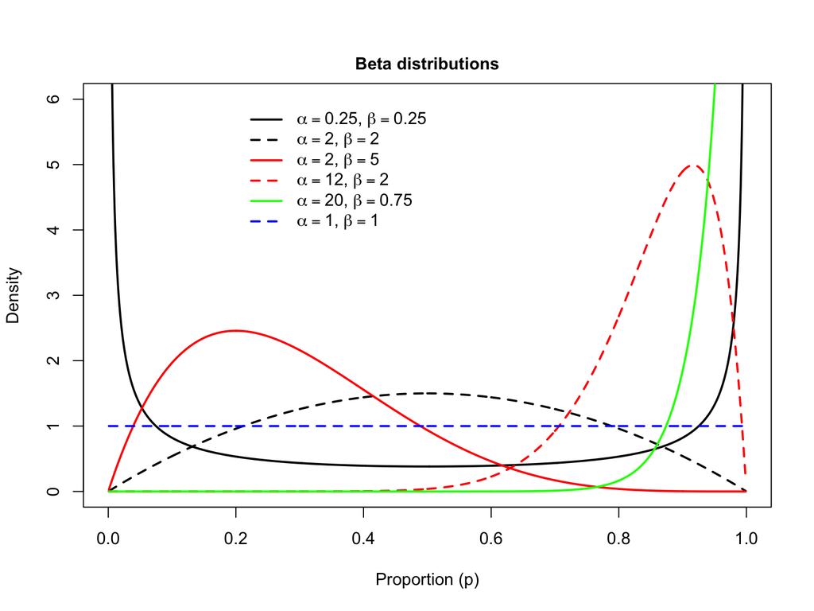

```r
aseq <- seq(.001,.999,.001)
plot(aseq,dbeta(aseq,.25,.25), type='l', ylim=c(0,6), ylab='Density', xlab='Proportion (p)',lwd=2)
lines(aseq, dbeta(aseq,2,2),lty=2,lwd=2)
lines(aseq, dbeta(aseq,2,5),lty=1,col=2,lwd=2)
lines(aseq, dbeta(aseq,12,2),lty=2,col=2,lwd=2)
lines(aseq, dbeta(aseq,20,.75),lty=1,col='green',lwd=2)
lines(aseq, dbeta(aseq,1,1),lty=2,lwd=2, col=4)
legend(.2,6,c(expression(paste(alpha==.25,', ', beta==.25)), expression(paste(alpha==2,', ',beta==2)), expression(paste(alpha==2,', ', beta==5)), expression(paste(alpha==12,', ',beta==2)), expression(paste(alpha==20,', ',beta==.75)), expression(paste(alpha==1,', ', beta==1))), lty=c(1,2,1,2,1,2), col=c(1,1,2,2,'green',4), cex=1,bty='n',lwd=rep(2,6))
mtext(side=3,line=.5,'Beta distributions',cex=1, font=2)
```

# Beta distribution

- $x \sim \mbox{Beta}(\alpha, \beta)$
- $f(x;\alpha,\beta) = \frac{\Gamma(\alpha + \beta)}{\Gamma(\alpha) \Gamma(\beta)} x^{\alpha - 1}(1 - x)^{\beta - 1}$
- $E(x) = \frac{\alpha}{\alpha + \beta}$
- when $\alpha = \beta = 1$, Beta distribution reduces to UNIF(0, 1)

# Gamma distribution

$$f(x;k,\theta) = \frac{1}{\Gamma(k) \theta^k} x^{k-1}e^{-\frac{x}{\theta}}$$

- $k$: shape parameter
- $\theta$: scale parameter

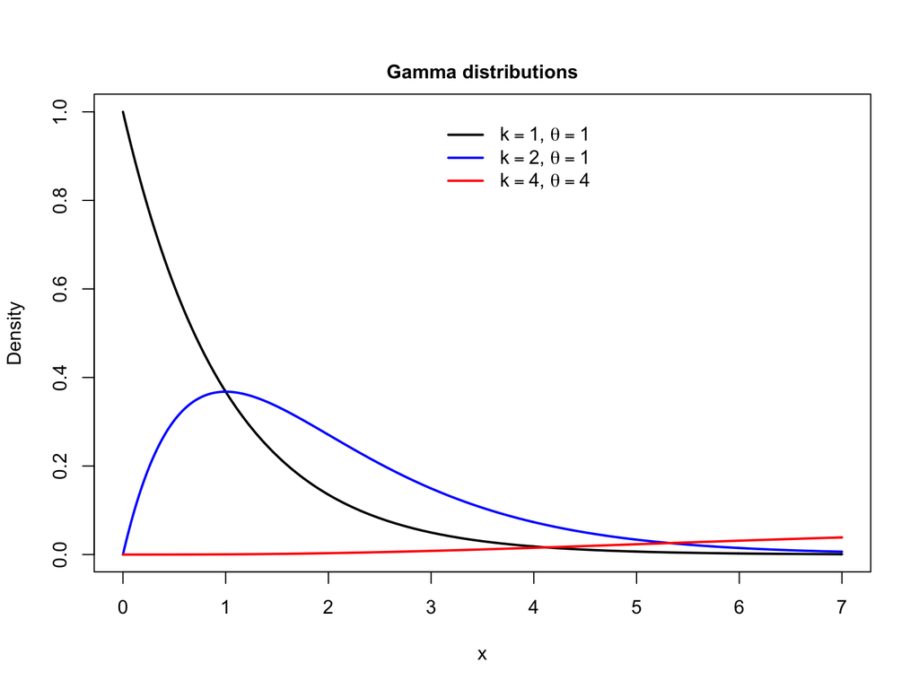

```r
aseq <- seq(0,7,.01)
plot(aseq,dgamma(aseq,shape=1,scale=1),type='l', xlab='x', ylab='Density', lwd=2)
lines(aseq,dgamma(aseq,shape=2,scale=1),col=4, lwd=2)
lines(aseq,dgamma(aseq,shape=4,scale=4),col=2, lwd=2)
legend(3,1,c(expression(paste(k==1,', ',theta==1,sep=' ')), expression(paste(k==2,', ',theta==1,sep=' ')), expression(paste(k==4,', ', theta==4,sep=' '))), col=c(1,4,2), lty=c(1,1,1), lwd=c(2,2,2), cex=1, bty='n')
mtext(side=3,line=.5,'Gamma distributions',cex=1, font=2)
```

# Gamma distribution

- $x \sim \mbox{Gamma}(k, \theta)$
- $f(x;k,\theta) = \frac{1}{\Gamma(k) \theta^k} x^{k-1}e^{-\frac{x}{\theta}}$
- $y \sim \mbox{EXP}(\theta)$ if $y \sim \mbox{Gamma}(1, \theta)$
- $y \sim \chi^2(v)$ if $y \sim \mbox{Gamma}(v/2, 2)$

# log normal distribution

A positive random variable $X$ is log-normally distributed if the logarithm of X is normally distributed,
$$\ln(X) \sim N(\mu, \sigma^2)$$

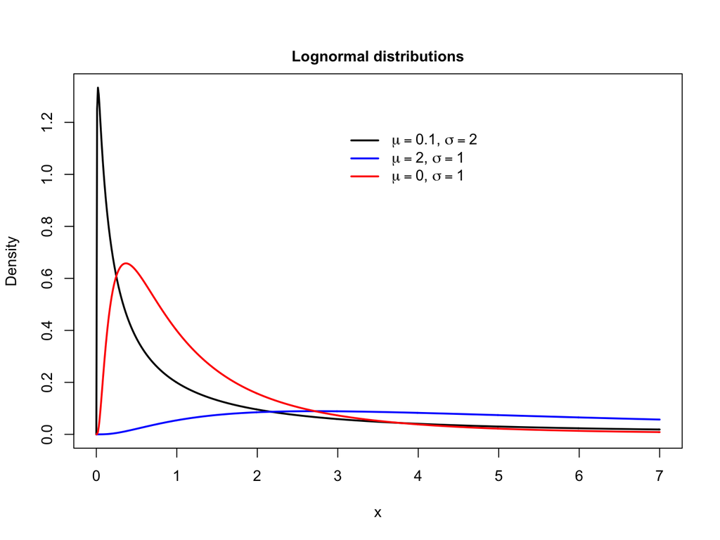

```r
aseq <- seq(0,7,.01)
plot(aseq,dlnorm(aseq,.1,2),type='l', xlab='x', ylab='Density', lwd=2)
lines(aseq,dlnorm(aseq,2,1),col=4, lwd=2)
lines(aseq,dlnorm(aseq,0,1),col=2, lwd=2)
legend(3,1.2,c(expression(paste(mu==0.1,', ',sigma==2,sep=' ')), expression(paste(mu==2,', ',sigma==1,sep=' ')), expression(paste(mu==0,', ',sigma==1,sep=' '))), col=c(1,4,2), lty=c(1,1,1), lwd=c(2,2,2), cex=1,bty='n')
mtext(side=3,line=.5,'Lognormal distributions',cex=1, font=2)
```

# samples from Normal distribution

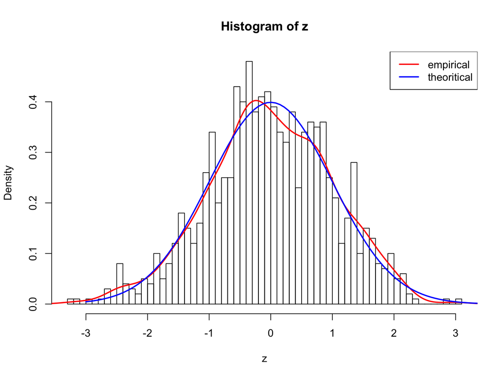

```r
set.seed(32608)
z <- rnorm(1000)
hist(z,nclass=50, freq = F)
lines(density(z), col=2, lwd=2)
curve(dnorm, from = -3, to = 4 ,col=4, lwd=2, add = T)
legend("topright", c("empirical", "theoritical"), col=c(2,4), lwd=c(2,2))
```

# Check CDF

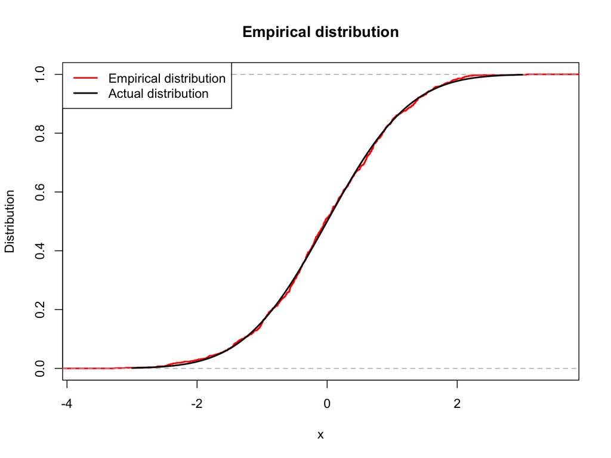

```r
set.seed(32608)
z <- rnorm(1000)
plot(ecdf(z), ylab="Distribution", main="Empirical distribution",
     lwd=2, col="red")
curve(pnorm, from = -3, to = 3, lwd=2, add = T)
legend("topleft", legend=c("Empirical distribution", "Actual distribution"),
       lwd=2, col=c("red","black"))
```

# In class exercise: Verify weak law of large number

The **weak law of large number** states the sample average converges in probability towards the expected value.

$$\frac{1}{n} \sum_{i=1}^n X_i \rightarrow \mathbb{E}(X)$$

```r
n <- 10^seq(2,8)
errors <- numeric(length(n))

for(i in seq_along(n)){
  set.seed(i)
  an <- n[i]
  ax <- rexp(an)
  errors[i] <- mean(ax) - 1
}

plot(n, errors, log = "xy")
```

[output not shown]

# p-value

- p-value:
  - When null hypothesis is true, the probability that the null statistics is as extreme or more extreme than the observed statistics.

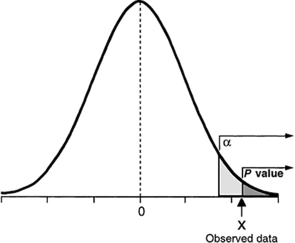

- p-value is the cumulative density, can be computed by pnorm() function

# p-value example

- E.g Null is $N(0,1)$, an observed statistics is 2.
  - one sided test, p-value is

  ```r
  pnorm(q = 2, mean = 0, sd = 1, lower.tail = FALSE) ## default: lower.tail = TRUE
  ```

  ```
  ## [1] 0.02275013
  ```

  - two sided test, p-value is

  ```r
  pnorm(q = 2, mean = 0, sd = 1, lower.tail = FALSE) + pnorm(q = - 2, mean = 0, sd = 1, lower.tail = TRUE)
  ```

  ```
  ## [1] 0.04550026
  ```

# quantile: qnorm()

- qnorm() calculates: given the area under the density curve (cumulative density), what is the quantile to generate such cumulative density?

```r
qnorm(p = 0.975, mean = 0, sd = 1, lower.tail = TRUE)
```

```
## [1] 1.959964
```

```r
qnorm(p = 0.025, mean = 0, sd = 1, lower.tail = TRUE)
```

```
## [1] -1.959964
```

- this is why 1.96 corresponds to 95% confidence interval.

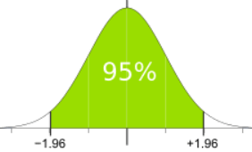

# Multi-variate normal distribution

$$X \sim N(
\begin{pmatrix}
\mu_1 \\
\mu_2
\end{pmatrix},
\begin{pmatrix}
\sigma_{11} & \sigma_{12} \\
\sigma_{21} & \sigma_{22}
\end{pmatrix}
)$$

```r
mu <- c(0,0)
Sigma <- matrix(c(10,3,3,2),2,2)
Sigma
```

```
##      [,1] [,2]
## [1,]   10    3
## [2,]    3    2
```

```r
var(MASS::mvrnorm(n = 1000, mu, Sigma))
```

```
##          [,1]     [,2]
## [1,] 9.470288 3.032126
## [2,] 3.032126 2.142785
```

# Multi-variate normal distribution simulation

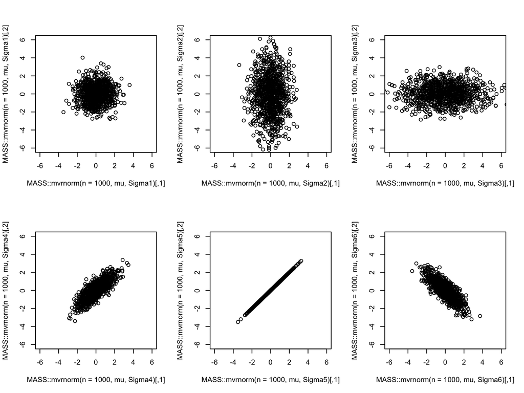

```r
mu <- c(0,0)
Sigma1 <- matrix(c(1,0,0,1),2,2)
Sigma2 <- matrix(c(1,0,0,5),2,2)
Sigma3 <- matrix(c(5,0,0,1),2,2)
Sigma4 <- matrix(c(1,0.8,0.8,1),2,2)
Sigma5 <- matrix(c(1,1,1,1),2,2)
Sigma6 <- matrix(c(1,-0.8,-0.8,1),2,2)
arange <- c(-6,6)
par(mfrow=c(2,3))
plot(MASS::mvrnorm(n = 1000, mu, Sigma1), xlim=arange, ylim=arange)
plot(MASS::mvrnorm(n = 1000, mu, Sigma2), xlim=arange, ylim=arange)
plot(MASS::mvrnorm(n = 1000, mu, Sigma3), xlim=arange, ylim=arange)
plot(MASS::mvrnorm(n = 1000, mu, Sigma4), xlim=arange, ylim=arange)
plot(MASS::mvrnorm(n = 1000, mu, Sigma5), xlim=arange, ylim=arange)
plot(MASS::mvrnorm(n = 1000, mu, Sigma6), xlim=arange, ylim=arange)
```

# Truncated distribution

```r
library(truncdist)
# dtrunc
# rtrunc
# ptrunc
# qtrunc
```

# generate samples from truncated normal distribution

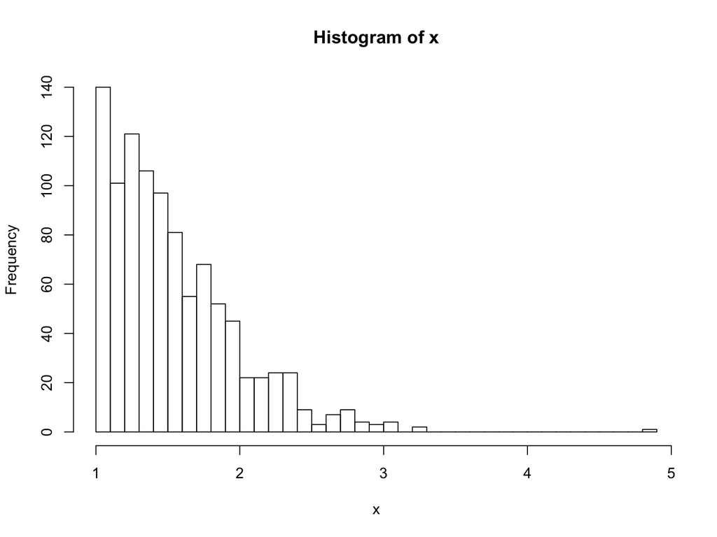

```r
x <- rtrunc( 1000, spec="norm", a=1, b=Inf )
hist(x, nclass = 50)
```

# density of truncated normal distribution

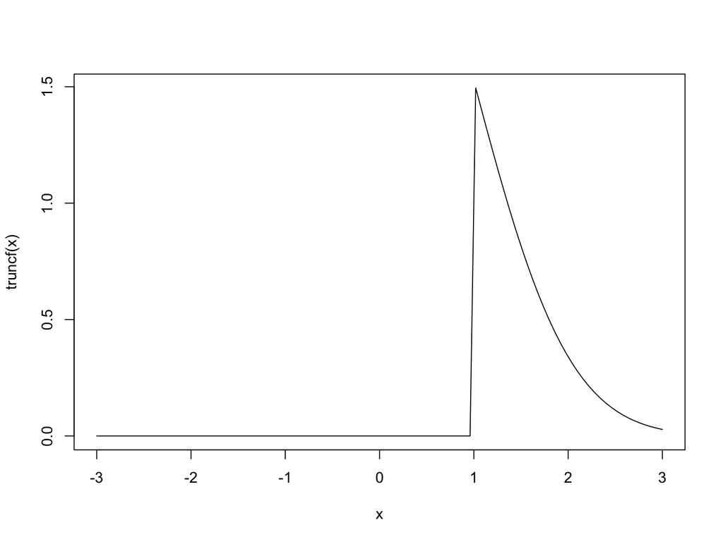

```r
truncf <- function(x) dtrunc(x, spec="norm", a=1, b=Inf )
curve(truncf, from = -3, to = 3)
```

# What kinds of distribution (spec) does this function support

- Seems to be all distributions available in r* (e.g. rnorm).

```r
dtrunc(0.5, spec="norm", a=-2, b=Inf )
```

```
## [1] 0.3602613
```

```r
dtrunc(0.5, spec="beta", shape1=2, shape2 = 2, a=0.3, b=Inf )
```

```
## [1] 1.913265
```

```r
dtrunc(0.5, spec="gamma", shape=2, rate = 2, a=0.3, b=Inf )
```

```
## [1] 0.8379001
```

# Another way generate random samples

- In the era without R, how people generate random samples from a distribution?
- Inverse CDF transformation

# CDF of any distribution function follows UNIF(0,1)

- $X$ is random variable from certain distribution.
- $F_X$ is CDF of $X$, assume to be continuous and increasing.
- Define $Z = F_X(X)$ and range of $Z$ is $[0, 1]$.

$$F_Z(y) = P(F_X(X) \le y) = P(X \le F_X^{-1}(y)) = F_X(F_X^{-1}(y)) = y$$
- If $U$ is a uniform random variable who takes values in $[0, 1]$,
$$F_U(y) = \int_{-\infty}^y f_U(u) du = \int_0^y du = y$$

Thus $Z \sim UNIF(0, 1)$

- Therefore, instead of directly sampling from $X$, we can sample from $Z \sim UNIF(0, 1)$ and calculate $F_X^{-1}(Z)$.

# Beta distribution

- $x \sim \mbox{Beta}(\alpha, \beta)$
- $f(x;\alpha,\beta) = \frac{\Gamma(\alpha + \beta)}{\Gamma(\alpha) \Gamma(\beta)} x^{\alpha - 1}(1 - x)^{\beta - 1}$
- Beta(3,1)
- PDF: $f(x) = 3x^2$
- CDF: $F(x) = x^3$
- Inverse CDF: $F^{-1}(x) = x^{1/3}$
- Two approaches:
  - directly sample from Beta(3,1)
  - sample from UNIF(0, 1) and take inverse CDF transformation

# Beta distribution (two approaches)

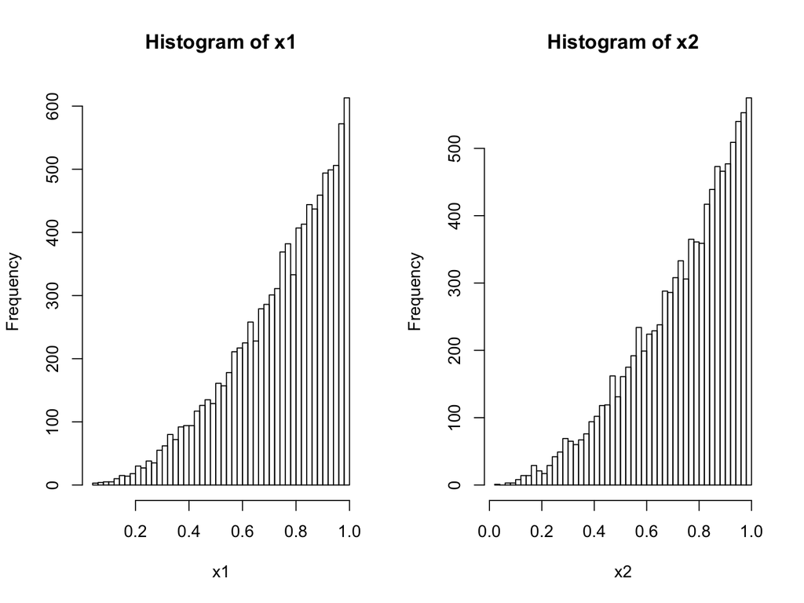

```r
set.seed(32611)
n <- 10000
x1 <- rbeta(n, 3, 1)
x2_0 <- runif(n)
x2 <- x2_0^{1/3}

par(mfrow=c(1,2))
hist(x1, nclass=50)
hist(x2, nclass=50)
```

# Compare direct sampling and inverse CDF sampling (In class exercise)

1. directly sample n=1000 samples from N(1,2)
2. use inverse CDF method to sample n=1000 from N(1,2) (hint: consider qnorm function)
3. Compare theoritical CDF, empirical CDF from 1 and empirical CDF from 2.
4. Using qq-plot to compare empirical CDF from 1 and empirical CDF from 2.